# Multiple Regression Analysis Final Report

```r
dat2014_ed |> filter(squared_error > 4) |> dplyr::select(Country)
```

```
##   Country
## 1   Italy
```

- model 3: split models_developing

```r
# 考慮continent間的差異
dat2013dming <- dat2013ing |> dummy_cols(select_columns = "continent")
dat2013dming <- dplyr::rename(dat2013dming, continent_North_America = `continent_North America`)
dat2013dming <- dplyr::rename(dat2013dming, continent_South_America = `continent_South America`)

# let Africa as the base continent
# R-squared: 0.8383
# 顯著的變數: Income_composition_of_resources(+), HIV_AIDS(-), Alcohol(-), Total_expenditure(+),  Population(+)
# 洲變數的影響都不顯著
# 係數變動方向合理
reging <- lm(Life_expectancy ~. -Year -Country -continent -continent_Africa -status, data = dat2013dming)
summary(reging)
```

```
##
## Call:
## lm(formula = Life_expectancy ~ . - Year - Country - continent -
##     continent_Africa - status, data = dat2013dming)
##
## Residuals:
##     Min      1Q  Median      3Q     Max
## -9.5218 -1.7483 -0.0784  1.8054 10.0396
##
## Coefficients:
##                                   Estimate Std. Error t value Pr(>|t|)
## (Intercept)                      4.508e+01  2.872e+00  15.694  < 2e-16 ***
## Adult_Mortality                 -5.965e-03  4.283e-03  -1.393  0.16727
## Alcohol                         -3.073e-01  1.390e-01  -2.211  0.02965 *
## Hepatitis_B                     -1.921e-02  2.069e-02  -0.928  0.35573
## Measles                          3.823e-05  8.204e-05   0.466  0.64237
## BMI                              2.426e-03  2.656e-02   0.091  0.92741
## under_five_deaths               -3.865e-03  3.825e-03  -1.010  0.31510
## Polio                            7.537e-03  1.665e-02   0.453  0.65187
## Total_expenditure                3.661e-01  1.450e-01   2.525  0.01339 *
## Diphtheria                       4.603e-02  2.932e-02   1.570  0.12004
## HIV_AIDS                        -9.134e-01  2.871e-01  -3.182  0.00203 **
## GDP                              7.607e-05  4.854e-05   1.567  0.12068
## Population                       2.541e-08  1.248e-08   2.035  0.04485 *
## thinness_1_19_years             -2.762e-02  1.049e-01  -0.263  0.79291
## Income_composition_of_resources  3.948e+01  7.321e+00   5.393 5.88e-07 ***
## Schooling                       -4.293e-01  3.385e-01  -1.268  0.20811
## continent_Asia                   4.579e-01  1.118e+00   0.410  0.68306
## continent_Europe                 2.471e+00  1.654e+00   1.493  0.13895
## continent_North_America          2.495e+00  1.357e+00   1.839  0.06940 .
## continent_Oceania                1.113e+00  1.650e+00   0.675  0.50153
## continent_South_America          2.669e+00  1.554e+00   1.717  0.08951 .
## ---
## Signif. codes:  0 '***' 0.001 '**' 0.01 '*' 0.05 '.' 0.1 ' ' 1
##
## Residual standard error: 3.065 on 87 degrees of freedom
## Multiple R-squared:  0.8685, Adjusted R-squared:  0.8383
## F-statistic: 28.73 on 20 and 87 DF,  p-value: < 2.2e-16
```

```r
# model diagnosis
# from test
# check normality: shapiro wilk test
shapiro.test(reging$residuals) # normal
```

```
##
##  Shapiro-Wilk normality test
##
## data:  reging$residuals
## W = 0.97655, p-value = 0.05315
```

```r
# check heteroskedastic
bptest(reging) # no  heteroscedasticity
```

```
##
##  studentized Breusch-Pagan test
##
## data:  reging
## BP = 14.124, df = 20, p-value = 0.8241
```

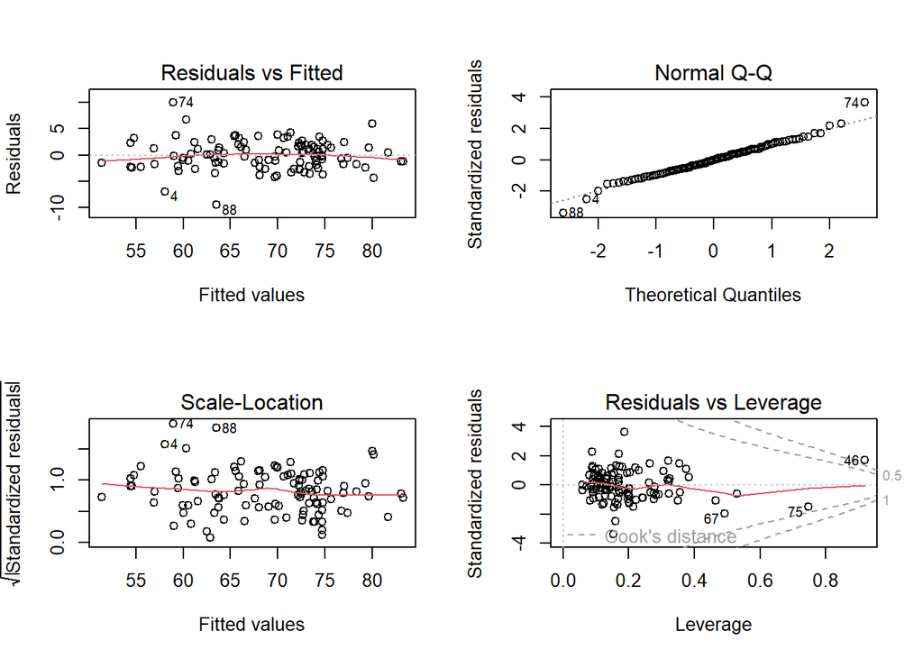

```r
# from plots
par(mfrow = c(2,2))
plot(reging)
```

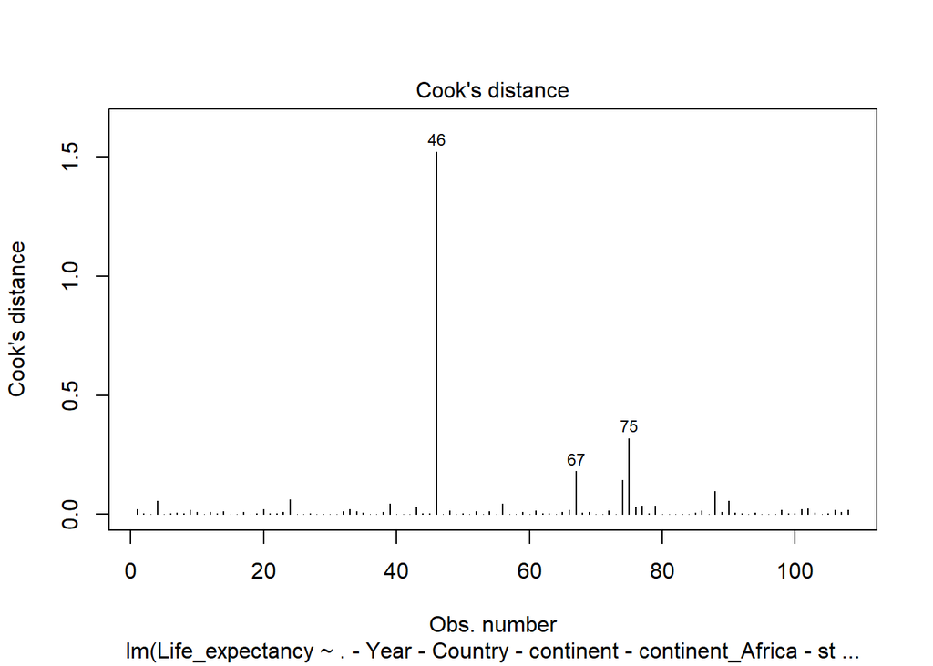

```r
# check influential point by cook's distance
par(mfrow = c(1,1))
plot(reging, which = 4)
```

```r
dat2013dming$Country[46] # india
```

```
## [1] "India"
```

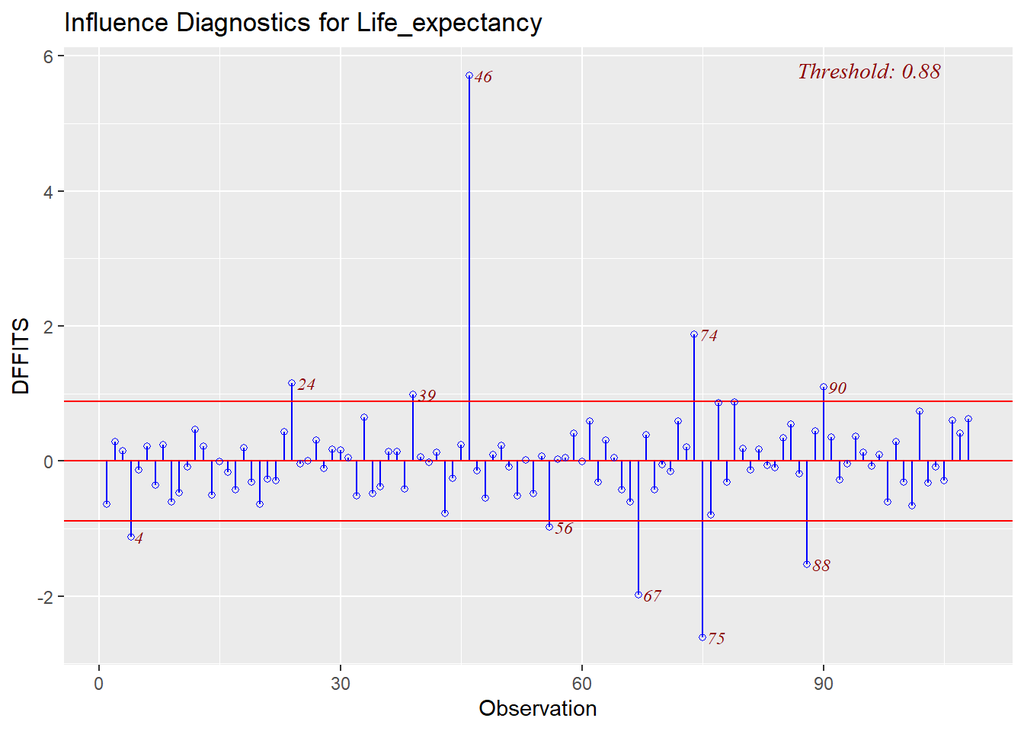

```r
# DFFITS Plot
# cutoff: 2*sqrt(21/108) = 0.88
ols_plot_dffits(reging)
```

```r
# leverage points (hii > 2*21/108=0.39)
# Canada, India, Lesotho, Montenegro, Nigeria
dat2013dming$Country[which(lm.influence(reging)$hat > 0.39)]
```

```
## [1] "Canada"     "India"      "Lesotho"    "Montenegro" "Nigeria"
```

```r
dat2013dming$continent[which(lm.influence(reging)$hat > 0.39)] # 分布於四大洲
```

```
## [1] "North America" "Asia"          "Africa"        "Europe"
## [5] "Africa"
```

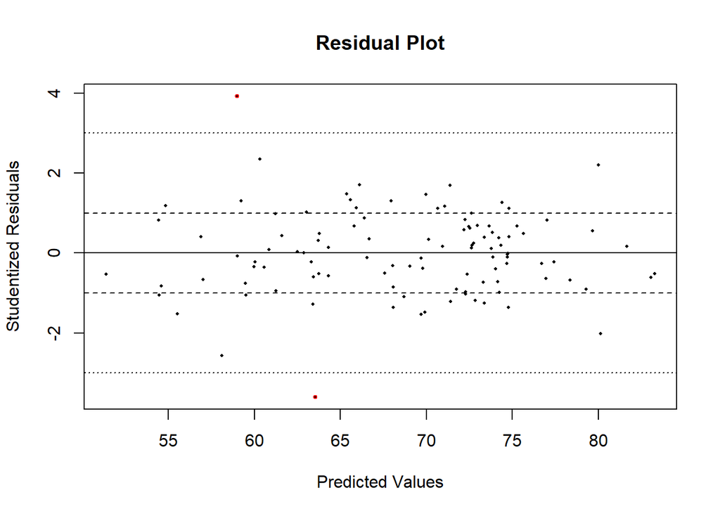

```r
# outlier detection
# studentized residual plot
# handyplots: threshold = +-3 (common)
resplot(reging, highlight.outliers = TRUE, residuals = c("student"))
```

```r
# Niger, Sierra Leone
dat2013dming$Country[which(studres(reging) >= 3 | studres(reging) <= -3)] # 在 full model 也是 outliers
```

```
## [1] "Niger"        "Sierra Leone"
```

```r
dat2013dming$continent[which(studres(reging) >= 3 | studres(reging) <= -3)]
```

```
## [1] "Africa" "Africa"
```

```r
# remove outlier and influential point
# R-squared: 0.8804
# 顯著的變數: Income_composition_of_resources(+), Total_expenditure(+), HIV_AIDS(-), Population(+), Adult_Mortality(-), Alcohol(-), under_five_deaths(-)
# 洲變數影響變顯著: continent_North_America(+), continent_South_America(+)
# 係數變動方向合理
tdat2013dming <- dat2013dming |> filter(Country != "Niger") |> filter(Country != "Sierra Leone") |> filter(Country != "India")
treging <- lm(Life_expectancy ~. -Year -Country -continent -continent_Africa -status, data = tdat2013dming)
summary(treging)
```

```
##
## Call:
## lm(formula = Life_expectancy ~ . - Year - Country - continent -
##     continent_Africa - status, data = tdat2013dming)
##
## Residuals:
##    Min     1Q Median     3Q    Max
## -7.320 -1.326  0.120  1.520  5.912
##
## Coefficients:
##                                   Estimate Std. Error t value Pr(>|t|)
## (Intercept)                      4.465e+01  2.760e+00  16.174  < 2e-16 ***
## Adult_Mortality                 -8.892e-03  3.754e-03  -2.368 0.020156 *
## Alcohol                         -3.030e-01  1.192e-01  -2.542 0.012852 *
## Hepatitis_B                     -1.401e-02  1.789e-02  -0.783 0.435994
## Measles                          2.332e-04  1.201e-04   1.942 0.055536 .
## BMI                             -6.144e-04  2.282e-02  -0.027 0.978587
## under_five_deaths               -1.865e-02  8.707e-03  -2.142 0.035057 *
## Polio                            6.875e-03  1.429e-02   0.481 0.631771
## Total_expenditure                4.518e-01  1.277e-01   3.539 0.000658 ***
## Diphtheria                       3.835e-02  2.541e-02   1.509 0.135015
## HIV_AIDS                        -7.831e-01  2.491e-01  -3.144 0.002301 **
## GDP                              7.262e-05  4.194e-05   1.731 0.087040 .
## Population                       3.620e-08  1.303e-08   2.779 0.006735 **
## thinness_1_19_years              5.704e-02  9.305e-02   0.613 0.541536
## Income_composition_of_resources  3.647e+01  6.316e+00   5.775 1.26e-07 ***
## Schooling                       -2.442e-01  2.976e-01  -0.821 0.414224
## continent_Asia                   2.419e-01  9.611e-01   0.252 0.801872
## continent_Europe                 2.444e+00  1.431e+00   1.708 0.091402 .
## continent_North_America          2.676e+00  1.170e+00   2.287 0.024722 *
## continent_Oceania                1.630e+00  1.423e+00   1.146 0.255200
## continent_South_America          2.938e+00  1.334e+00   2.202 0.030404 *
## ---
## Signif. codes:  0 '***' 0.001 '**' 0.01 '*' 0.05 '.' 0.1 ' ' 1
##
## Residual standard error: 2.625 on 84 degrees of freedom
## Multiple R-squared:  0.9034, Adjusted R-squared:  0.8804
## F-statistic: 39.29 on 20 and 84 DF,  p-value: < 2.2e-16
```

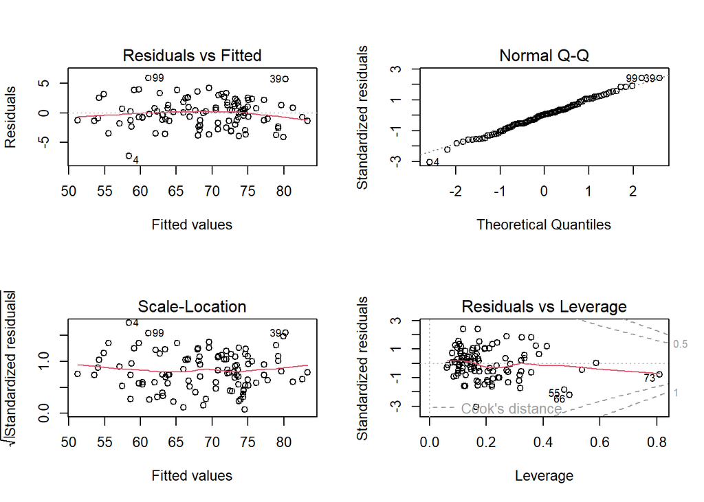

```r
par(mfrow = c(2,2))
plot(treging)
```

```r
# model diagnosis
# from test
# check normality: shapiro wilk test
shapiro.test(treging$residuals) # normal
```

```
##
##  Shapiro-Wilk normality test
##
## data:  treging$residuals
## W = 0.99134, p-value = 0.7436
```

```r
# check heteroskedastic
bptest(treging) # no heteroscedasticity
```

```
##
##  studentized Breusch-Pagan test
##
## data:  treging
## BP = 18.904, df = 20, p-value = 0.5281
```

```r
# model selection
# 三種方式選到的變數不同
# 因為 backward 刪除的變數和 forward 留下的幾乎相對，所以被刪除的變數不考慮放入模型，選擇forward
# 以 forward 和 stepwise 為候選模型，發現兩者雖然變數個數相差很多，但模型表現類似，表示 stepwise 是比較精簡的模型；
# 然而，forward 多的變數仍然有顯著的，所以決定兩個都預測，比較 PMSE 。
# stepwise 在修正後模型選到的變數和 full model 的候選模型完全相同!!
ols_step_forward_p(reging)
```

```
##
##                                        Selection Summary
## ------------------------------------------------------------------------------------------------
##         Variable                                         Adj.
## Step                Entered                R-Square    R-Square     C(p)        AIC        RMSE
## ------------------------------------------------------------------------------------------------
##    1    Income_composition_of_resources      0.7428      0.7404    66.1797    603.5407    3.8837
##    2    HIV_AIDS                             0.8138      0.8102    21.2129    570.6630    3.3203
##    3    Total_expenditure                    0.8315      0.8266    11.4943    561.8694    3.1737
##    4    Population                           0.8383      0.8320     8.9983    559.4242    3.1241
##    5    under_five_deaths                    0.8449      0.8373     6.6219    556.9139    3.0745
##    6    Adult_Mortality                      0.8488      0.8398     6.0678    556.1920    3.0510
##    7    Alcohol                              0.8505      0.8400     6.9367    556.9642    3.0488
##    8    continent_North_America              0.8531      0.8413     7.1763    557.0252    3.0368
##    9    GDP                                  0.8557      0.8425     7.4615    557.1025    3.0252
##   10    continent_South_America              0.8582      0.8436     7.8292    557.2398    3.0146
##   11    continent_Europe                     0.8606      0.8446     8.2278    557.3806    3.0043
##   12    Diphtheria                           0.8631      0.8458     8.5966    557.4534    2.9933
##   13    Schooling                            0.8654      0.8468     9.0483    557.5916    2.9833
## ------------------------------------------------------------------------------------------------
```

```r
ols_step_backward_p(reging)
```

```
##
##
##                                 Elimination Summary
## ------------------------------------------------------------------------------------
##         Variable                             Adj.
## Step          Removed          R-Square    R-Square     C(p)        AIC        RMSE
## ------------------------------------------------------------------------------------
##    1    BMI                      0.8685      0.8401    19.0083    567.0888    3.0478
##    2    thinness_1_19_years      0.8684      0.8417    17.0887    565.1885    3.0320
##    3    continent_Asia           0.8682      0.8433    15.2017    563.3285    3.0171
##    4    Polio                     0.868      0.8448    13.3436    561.5042    3.0029
##    5    Measles                  0.8675      0.8459    11.6606    559.8954    2.9920
##    6    Hepatitis_B              0.8667      0.8467    10.1792    558.5324    2.9846
##    7    under_five_deaths        0.8656       0.847     8.9387    557.4587    2.9815
##    8    continent_Oceania        0.8642      0.8471     7.8411    556.5490    2.9807
## ------------------------------------------------------------------------------------
```

```r
ols_step_both_p(reging)
```

```
##
##                                          Stepwise Selection Summary
## ------------------------------------------------------------------------------------------------------------
##                                             Added/                   Adj.
## Step               Variable                Removed     R-Square    R-Square     C(p)        AIC        RMSE
## ------------------------------------------------------------------------------------------------------------
##    1    Income_composition_of_resources    addition       0.743       0.740    66.1800    603.5407    3.8837
##    2               HIV_AIDS                addition       0.814       0.810    21.2130    570.6630    3.3203
##    3           Total_expenditure           addition       0.831       0.827    11.4940    561.8694    3.1737
##    4              Population               addition       0.838       0.832     8.9980    559.4242    3.1241
##    5           under_five_deaths           addition       0.845       0.837     6.6220    556.9139    3.0745
## ------------------------------------------------------------------------------------------------------------
```

```r
ols_step_forward_p(treging)
```

```
##
##                                        Selection Summary
## ------------------------------------------------------------------------------------------------
##         Variable                                         Adj.
## Step                Entered                R-Square    R-Square     C(p)        AIC        RMSE
## ------------------------------------------------------------------------------------------------
##    1    Income_composition_of_resources      0.7705      0.7683    98.5643    574.1060    3.6544
##    2    HIV_AIDS                             0.8352      0.8320    44.3354    541.3563    3.1123
##    3    Total_expenditure                    0.8600      0.8558    24.8020    526.2633    2.8831
##    4    Adult_Mortality                      0.8720      0.8668    16.3577    518.8501    2.7705
##    5    Population                           0.8779      0.8717    13.1872    515.8580    2.7190
##    6    under_five_deaths                    0.8838      0.8767    10.0831    512.6857    2.6664
##    7    Diphtheria                           0.8858      0.8775    10.3582    512.8784    2.6571
##    8    continent_North_America              0.8876      0.8782    10.7671    513.1834    2.6495
##    9    Alcohol                              0.8902      0.8798    10.5062    512.7268    2.6324
##   10    continent_South_America              0.8925      0.8811    10.5056    512.5039    2.6185
##   11    GDP                                  0.8947      0.8823    10.5454    512.2793    2.6048
##   12    Measles                              0.8972      0.8838    10.3768    511.7621    2.5877
##   13    continent_Europe                     0.9000      0.8857     9.9637    510.8882    2.5665
## ------------------------------------------------------------------------------------------------
```

```r
ols_step_backward_p(treging)
```

```
##
##
##                                 Elimination Summary
## ------------------------------------------------------------------------------------
##         Variable                             Adj.
## Step          Removed          R-Square    R-Square     C(p)        AIC        RMSE
## ------------------------------------------------------------------------------------
##    1    BMI                      0.9034      0.8818    19.0007    519.2483    2.6099
##    2    continent_Asia           0.9033      0.8831    17.0665    517.3305    2.5957
##    3    Polio                    0.9031      0.8842    15.2765    515.5925    2.5840
##    4    Hepatitis_B              0.9025      0.8848    13.7707    514.2064    2.5768
##    5    thinness_1_19_years      0.9018      0.8853    12.3757    512.9531    2.5714
##    6    Schooling                0.9012      0.8858    10.9568    511.6654    2.5658
##    7    continent_Oceania         0.900      0.8857     9.9637    510.8882    2.5665
## ------------------------------------------------------------------------------------
```

```r
ols_step_both_p(treging)
```

```
##
##                                          Stepwise Selection Summary
## ------------------------------------------------------------------------------------------------------------
##                                             Added/                   Adj.
## Step               Variable                Removed     R-Square    R-Square     C(p)        AIC        RMSE
## ------------------------------------------------------------------------------------------------------------
##    1    Income_composition_of_resources    addition       0.771       0.768    98.5640    574.1060    3.6544
##    2               HIV_AIDS                addition       0.835       0.832    44.3350    541.3563    3.1123
##    3           Total_expenditure           addition       0.860       0.856    24.8020    526.2633    2.8831
##    4            Adult_Mortality            addition       0.872       0.867    16.3580    518.8501    2.7705
##    5              Population               addition       0.878       0.872    13.1870    515.8580    2.7190
##    6           under_five_deaths           addition       0.884       0.877    10.0830    512.6857    2.6664
## ------------------------------------------------------------------------------------------------------------
```

```r
# R-squared: 0.8827
# 顯著的變數: Total_expenditure(+), HIV_AIDS(-), Income_composition_of_resources(+), Population(+), Adult_Mortality(-), Alcohol(-)
# 洲變數影響有顯著: continent_North_America(+)
# 係數變動方向合理
reging_f <- lm(Life_expectancy ~ Income_composition_of_resources + HIV_AIDS + Total_expenditure +
                 Adult_Mortality + Population + under_five_deaths +
                 GDP + Alcohol + Diphtheria + continent_North_America + continent_South_America + continent_Europe , data = tdat2013dming)
summary(reging_f)
```

```
##
## Call:
## lm(formula = Life_expectancy ~ Income_composition_of_resources +
##     HIV_AIDS + Total_expenditure + Adult_Mortality + Population +
##     under_five_deaths + GDP + Alcohol + Diphtheria + continent_North_America +
##     continent_South_America + continent_Europe, data = tdat2013dming)
##
## Residuals:
##     Min      1Q  Median      3Q     Max
## -7.2045 -1.5733 -0.2175  1.7332  6.9695
##
## Coefficients:
##                                   Estimate Std. Error t value Pr(>|t|)
## (Intercept)                      4.365e+01  2.310e+00  18.901  < 2e-16 ***
## Income_composition_of_resources  3.557e+01  3.154e+00  11.277  < 2e-16 ***
## HIV_AIDS                        -8.702e-01  2.256e-01  -3.857 0.000213 ***
## Total_expenditure                4.384e-01  1.224e-01   3.581 0.000549 ***
## Adult_Mortality                 -9.194e-03  3.638e-03  -2.527 0.013200 *
## Population                       2.394e-08  9.995e-09   2.395 0.018657 *
## under_five_deaths               -3.541e-03  3.471e-03  -1.020 0.310254
## GDP                              6.035e-05  4.005e-05   1.507 0.135267
## Alcohol                         -2.772e-01  1.146e-01  -2.419 0.017535 *
## Diphtheria                       2.565e-02  1.549e-02   1.655 0.101272
## continent_North_America          2.151e+00  9.403e-01   2.287 0.024472 *
## continent_South_America          1.923e+00  1.062e+00   1.810 0.073596 .
## continent_Europe                 1.334e+00  1.171e+00   1.139 0.257554
## ---
## Signif. codes:  0 '***' 0.001 '**' 0.01 '*' 0.05 '.' 0.1 ' ' 1
##
## Residual standard error: 2.601 on 92 degrees of freedom
## Multiple R-squared:  0.8962, Adjusted R-squared:  0.8827
## F-statistic:  66.2 on 12 and 92 DF,  p-value: < 2.2e-16
```

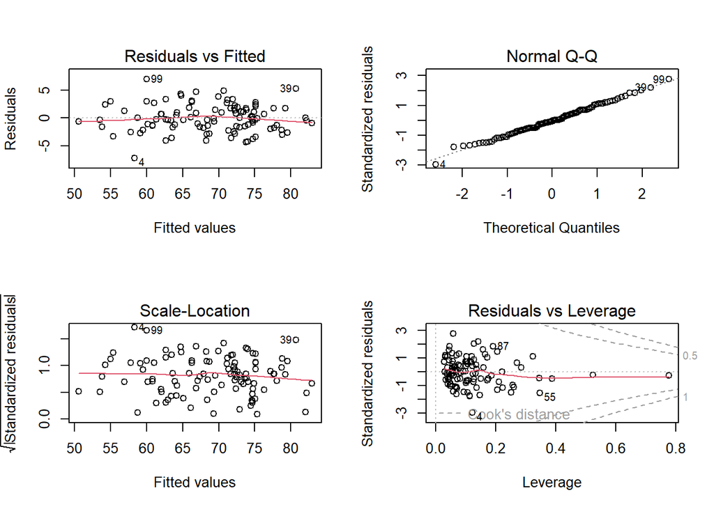

```r
par(mfrow = c(2,2))
plot(reging_f)
```

```r
# R-squared: 0.8767
# 顯著的變數: Total_expenditure(+), HIV_AIDS(-), Income_composition_of_resources(+), Population(+), Adult_Mortality(-), under_five_deaths(-)
# 係數變動方向合理
reging_s <- lm(Life_expectancy ~ Income_composition_of_resources + HIV_AIDS + Total_expenditure +
                 Adult_Mortality + Population + under_five_deaths, data = tdat2013dming)
summary(reging_s)
```

```
##
## Call:
## lm(formula = Life_expectancy ~ Income_composition_of_resources +
##     HIV_AIDS + Total_expenditure + Adult_Mortality + Population +
##     under_five_deaths, data = tdat2013dming)
##
## Residuals:
##    Min     1Q Median     3Q    Max
## -8.863 -1.668 -0.171  1.969  7.357
##
## Coefficients:
##                                   Estimate Std. Error t value Pr(>|t|)
## (Intercept)                      4.447e+01  1.954e+00  22.757  < 2e-16 ***
## Income_composition_of_resources  3.737e+01  2.392e+00  15.621  < 2e-16 ***
## HIV_AIDS                        -9.664e-01  2.230e-01  -4.334 3.55e-05 ***
## Total_expenditure                5.183e-01  1.202e-01   4.311 3.88e-05 ***
## Adult_Mortality                 -9.417e-03  3.676e-03  -2.562  0.01193 *
## Population                       2.988e-08  1.004e-08   2.976  0.00367 **
## under_five_deaths               -7.376e-03  3.316e-03  -2.224  0.02841 *
## ---
## Signif. codes:  0 '***' 0.001 '**' 0.01 '*' 0.05 '.' 0.1 ' ' 1
##
## Residual standard error: 2.666 on 98 degrees of freedom
## Multiple R-squared:  0.8838, Adjusted R-squared:  0.8767
## F-statistic: 124.2 on 6 and 98 DF,  p-value: < 2.2e-16
```

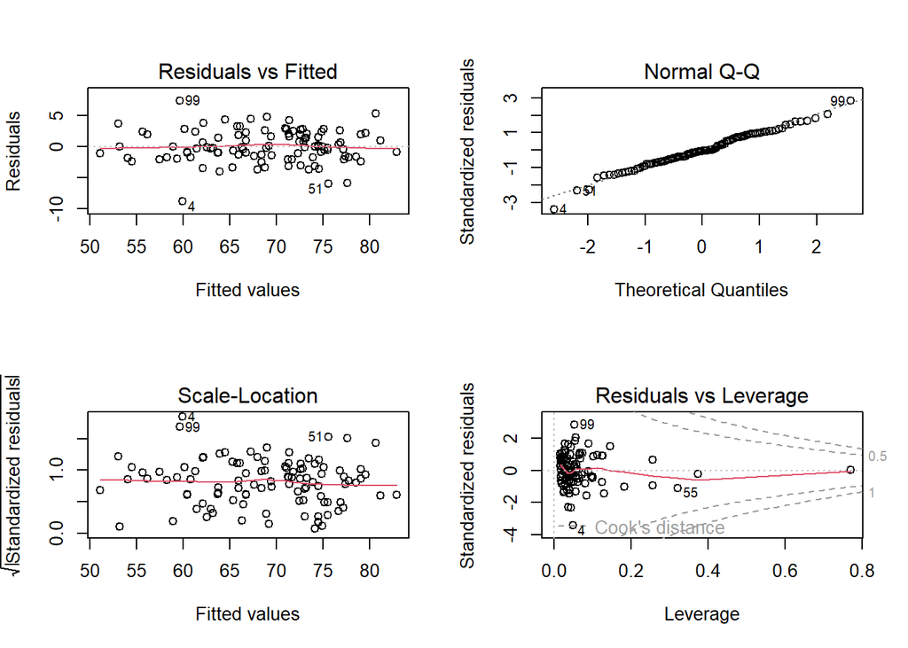

```r
par(mfrow = c(2,2))
plot(reging_s)
```

```r
# check multicollinearity
# no multicollinearity
ols_vif_tol(reging_f) # 變數很多但沒有共線性問題
```

```
##                          Variables Tolerance      VIF
## 1  Income_composition_of_resources 0.3568649 2.802181
## 2                         HIV_AIDS 0.4246555 2.354850
## 3                Total_expenditure 0.8487227 1.178241
## 4                  Adult_Mortality 0.4209579 2.375534
## 5                       Population 0.7376895 1.355584
## 6                under_five_deaths 0.6253846 1.599016
## 7                              GDP 0.6210347 1.610216
## 8                          Alcohol 0.4640053 2.155148
## 9                       Diphtheria 0.7833229 1.276613
## 10         continent_North_America 0.6715671 1.489054
## 11         continent_South_America 0.6623003 1.509889
## 12                continent_Europe 0.5993927 1.668355
```

```r
ols_vif_tol(reging_s) # 沒有共線性問題
```

```
##                         Variables Tolerance      VIF
## 1 Income_composition_of_resources 0.6519215 1.533927
## 2                        HIV_AIDS 0.4569165 2.188584
## 3               Total_expenditure 0.9248625 1.081242
## 4                 Adult_Mortality 0.4334592 2.307022
## 5                      Population 0.7689499 1.300475
## 6               under_five_deaths 0.7202399 1.388426
```

```r
# the best models for developing countries: reging_f and reging_s
# prediction in 2014
dat2014dming <- dat2014ing |> dummy_cols(select_columns = "continent")
dat2014dming <- dplyr::rename(dat2014dming, continent_North_America = `continent_North America`)
dat2014dming <- dplyr::rename(dat2014dming, continent_South_America = `continent_South America`)
tdat2014dming <- dat2014dming |> filter(Country != "Niger") |> filter(Country != "Sierra Leone") |> filter(Country != "India")
a <- rep(1,105)
## prediction in 2014 (reging_f)
b <- matrix(reging_f$coefficients, ncol = 1)
mat2014ing_f <- tdat2014dming |> dplyr::select(Income_composition_of_resources, HIV_AIDS, Total_expenditure,
                                               Adult_Mortality, Population, under_five_deaths, GDP,
                                               Alcohol, Diphtheria, continent_North_America, continent_South_America, continent_Europe ) |>
  mutate(a) |> relocate(a, .before = Income_composition_of_resources) |> as.matrix()
predicting_f <- as.numeric(mat2014ing_f %*% b)
squared_error_f <- (predicting_f - tdat2014dming$Life_expectancy)^2
dat2014_ing_f <- tdat2014dming |> dplyr::select(Country, continent, status, Life_expectancy) |> mutate(predicting_f, squared_error_f)
pmse_ing_f <- mean(squared_error_f) # 6.8
pmse_ing_f
```

```
## [1] 6.817353
```

```r
# 平均預期壽命: 69.168 (觀測值: 68.8546)
mean(predicting_f)
```

```
## [1] 69.16813
```

```r
mean(dat2014dming$Life_expectancy)
```

```
## [1] 68.85463
```

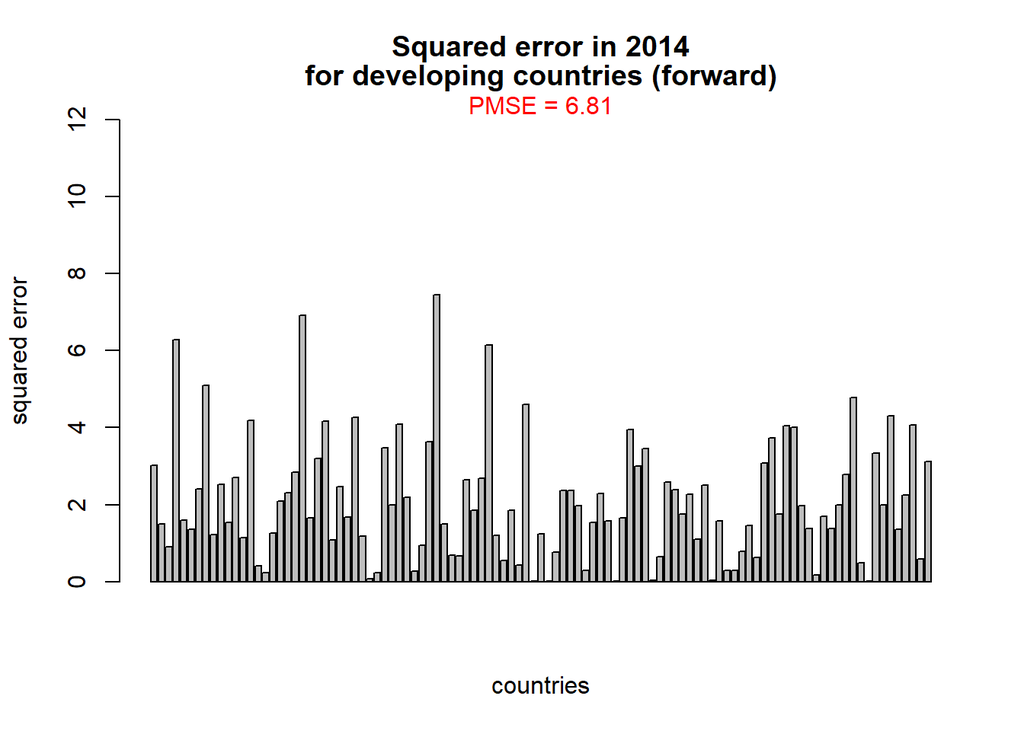

```r
par(mfrow = c(1,1))
barplot(abs(predicting_f - tdat2014dming$Life_expectancy),  ylim = c(0,12), ylab = "squared error", xlab = "countries",
        main = c(paste( "Squared error in 2014"), paste("for developing countries (forward)")))
mtext("PMSE = 6.81", side=3, col = "red", lwd = 2)
```

```r
dat2014_ing_f |> filter(squared_error_f > 4) |> group_by(continent) |> count()
```

```
## # A tibble: 6 × 2
## # Groups:   continent [6]
##   continent         n
##   <chr>         <int>
## 1 Africa           16
## 2 Asia             12
## 3 Europe            6
## 4 North America     5
## 5 Oceania           4
## 6 South America     2
```

```r
# prediction in 2014 (reging_s)
b <- matrix(reging_s$coefficients, ncol = 1)
mat2014ing_s <- tdat2014dming |> dplyr::select(Income_composition_of_resources, HIV_AIDS, Total_expenditure,
                                               Adult_Mortality, Population, under_five_deaths) |>
  mutate(a) |> relocate(a, .before = Income_composition_of_resources) |> as.matrix()
predicting_s <- as.numeric(mat2014ing_s %*% b)
squared_error_s <- (predicting_s - tdat2014dming$Life_expectancy)^2
dat2014_ing_s <- tdat2014dming |> dplyr::select(Country, continent, status, Life_expectancy) |> mutate(predicting_s, squared_error_s)
pmse_ing_s <- mean(squared_error_s)
pmse_ing_s
```

```
## [1] 7.266483
```

```r
# PMSE 雖然比 forward 大，但是在平均預期壽命的預測卻比較準確
# 平均預期壽命: 69.11297 (觀測值: 68.8546)
mean(predicting_s)
```

```
## [1] 69.11297
```

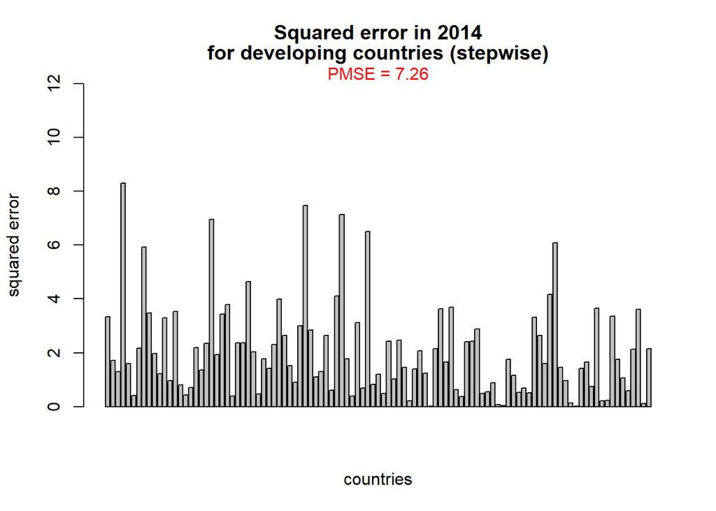

```r
par(mfrow = c(1,1))
barplot(abs(predicting_s - tdat2014dming$Life_expectancy),  ylim = c(0,12), ylab = "squared error", xlab = "countries",
        main = c(paste( "Squared error in 2014"), paste("for developing countries (stepwise)")))
mtext("PMSE = 7.26", side=3, col = "red", lwd = 2)
```

```r
dat2014_ing_s |> filter(squared_error_s > 4) |> group_by(continent) |> count()
```

```
## # A tibble: 6 × 2
## # Groups:   continent [6]
##   continent         n
##   <chr>         <int>
## 1 Africa           15
## 2 Asia             12
## 3 Europe            4
## 4 North America     9
## 5 Oceania           3
## 6 South America     2
```

### 七、結論與討論

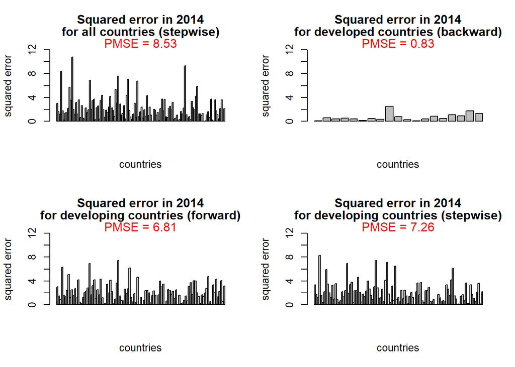

```r
par(mfrow = c(2,2))
barplot(abs(predictfull - tdat2014$Life_expectancy), ylim = c(0,12), ylab = "squared error", xlab = "countries",
        main = c(paste( "Squared error in 2014"), paste("for all countries (stepwise)")))
mtext("PMSE = 8.53", side=3, col = "red", lwd = 2)
barplot(abs(predicted - dat2013edd$Life_expectancy), ylim = c(0,12), ylab = "squared error", xlab = "countries",
        main = c(paste( "Squared error in 2014"), paste("for developed countries (backward)")))
mtext("PMSE = 0.83", side=3, col = "red", lwd = 2)
barplot(abs(predicting_f - tdat2014dming$Life_expectancy),  ylim = c(0,12), ylab = "squared error", xlab = "countries",
        main = c(paste( "Squared error in 2014"), paste("for developing countries (forward)")))
mtext("PMSE = 6.81", side=3, col = "red", lwd = 2)
barplot(abs(predicting_s - tdat2014dming$Life_expectancy),  ylim = c(0,12), ylab = "squared error", xlab = "countries",
        main = c(paste( "Squared error in 2014"), paste("for developing countries (stepwise)")))
mtext("PMSE = 7.26", side=3, col = "red", lwd = 2)
```

### 八、可能改進的方向

1. 考慮長期的趨勢
- 開發中以肯亞為例，已開發以法國為例
2. 現有資料缺乏性別資訊，日後應該要分別預測不同性別的預期壽命

[figure not shown]

```r
## developing
Kenya <- data |> filter(Country == "Kenya")
par(mfrow = c(2,3))
plot(Kenya$Year, Kenya$Alcohol, pch = 16)
plot(Kenya$Year, Kenya$`Adult Mortality`, pch = 16)
plot(Kenya$Year, Kenya$under_five_deaths, pch = 16)
plot(Kenya$Year, Kenya$Population, pch = 16)
plot(Kenya$Year, Kenya$HIV_AIDS, pch = 16)
plot(Kenya$Year, Kenya$Income_composition_of_resources, pch = 16)
```

[figure not shown]

```r
## developed
France <- data |> filter(Country == "France")
par(mfrow = c(2,3))
plot(France$Year, France$Alcohol, pch = 16)
plot(France$Year, France$`Adult Mortality`, pch = 16)
plot(France$Year, France$GDP, pch = 16)
plot(France$Year, France$`Total expenditure`, pch = 16)
plot(France$Year, France$Polio, pch = 16)
plot(France$Year, France$Hepatitis_B, pch = 16)
```

### 九、參考資料

- [程式碼及輸出結果](https://chang-web.github.io/R-selflearning/Multiple%20Linear%20Regression/report-code20221208.html)
- [資料來源_life expectancy](https://www.kaggle.com/datasets/kumarajarshi/life-expectancy-who)
- [資料來源_continents](https://worldpopulationreview.com/country-rankings/list-of-countries-by-continent)
- Literature
  1. [Machine Learning for Prognosis of Life Expectancy and Diseases](https://www.ijitee.org/portfolio-item/J91560881019/)
  2. [Machine Learning Techniques for Life Expectancy Prediction](https://www.warse.org/IJATCSE/static/pdf/file/ijatcse45942020.pdf)
  3. [Life Expectancy: Prediction & Analysis using ML](https://ieeexplore.ieee.org/document/9596123/)
  4. [Life Expectancy Prediction through Analysis of Immunization and HDI Factors using Machine Learning Regression Algorithms](https://online-journals.org/index.php/i-joe/article/view/33315)